# Risk Factor Analysis

## Outcome Variable

**Outcome Variable:** pers_wast

## Predictor Variables

**Intervention Variable:** mwtkg

**Adjustment Set:**

- arm
- W_mage
- meducyrs
- feducyrs
- single
- brthmon
- W_parity
- delta_W_mage
- delta_meducyrs
- delta_feducyrs
- delta_single
- delta_brthmon
- delta_W_parity

## Stratifying Variables

The analysis was stratified on these variable(s):

- agecat
- studyid
- country

## Data Summary

| agecat | studyid | country | mwtkg | pers_wast | n_cell | n |
| --- | --- | --- | --- | --- | --- | --- |
| 0-24 months | ki0047075b-MAL-ED | BANGLADESH | >=58 kg | 0 | 45 | 248 |
| 0-24 months | ki0047075b-MAL-ED | BANGLADESH | >=58 kg | 1 | 2 | 248 |
| 0-24 months | ki0047075b-MAL-ED | BANGLADESH | <52 kg | 0 | 149 | 248 |
| 0-24 months | ki0047075b-MAL-ED | BANGLADESH | <52 kg | 1 | 9 | 248 |
| 0-24 months | ki0047075b-MAL-ED | BANGLADESH | [52-58) kg | 0 | 41 | 248 |
| 0-24 months | ki0047075b-MAL-ED | BANGLADESH | [52-58) kg | 1 | 2 | 248 |
| 0-24 months | ki0047075b-MAL-ED | BRAZIL | >=58 kg | 0 | 139 | 216 |
| 0-24 months | ki0047075b-MAL-ED | BRAZIL | >=58 kg | 1 | 1 | 216 |
| 0-24 months | ki0047075b-MAL-ED | BRAZIL | <52 kg | 0 | 40 | 216 |
| 0-24 months | ki0047075b-MAL-ED | BRAZIL | <52 kg | 1 | 0 | 216 |
| 0-24 months | ki0047075b-MAL-ED | BRAZIL | [52-58) kg | 0 | 35 | 216 |
| 0-24 months | ki0047075b-MAL-ED | BRAZIL | [52-58) kg | 1 | 1 | 216 |
| 0-24 months | ki0047075b-MAL-ED | INDIA | >=58 kg | 0 | 39 | 240 |
| 0-24 months | ki0047075b-MAL-ED | INDIA | >=58 kg | 1 | 2 | 240 |
| 0-24 months | ki0047075b-MAL-ED | INDIA | <52 kg | 0 | 132 | 240 |
| 0-24 months | ki0047075b-MAL-ED | INDIA | <52 kg | 1 | 17 | 240 |
| 0-24 months | ki0047075b-MAL-ED | INDIA | [52-58) kg | 0 | 48 | 240 |
| 0-24 months | ki0047075b-MAL-ED | INDIA | [52-58) kg | 1 | 2 | 240 |
| 0-24 months | ki0047075b-MAL-ED | NEPAL | >=58 kg | 0 | 80 | 238 |
| 0-24 months | ki0047075b-MAL-ED | NEPAL | >=58 kg | 1 | 0 | 238 |
| 0-24 months | ki0047075b-MAL-ED | NEPAL | <52 kg | 0 | 73 | 238 |
| 0-24 months | ki0047075b-MAL-ED | NEPAL | <52 kg | 1 | 3 | 238 |
| 0-24 months | ki0047075b-MAL-ED | NEPAL | [52-58) kg | 0 | 81 | 238 |
| 0-24 months | ki0047075b-MAL-ED | NEPAL | [52-58) kg | 1 | 1 | 238 |
| 0-24 months | ki0047075b-MAL-ED | PERU | >=58 kg | 0 | 103 | 283 |
| 0-24 months | ki0047075b-MAL-ED | PERU | >=58 kg | 1 | 0 | 283 |
| 0-24 months | ki0047075b-MAL-ED | PERU | <52 kg | 0 | 110 | 283 |
| 0-24 months | ki0047075b-MAL-ED | PERU | <52 kg | 1 | 1 | 283 |
| 0-24 months | ki0047075b-MAL-ED | PERU | [52-58) kg | 0 | 69 | 283 |
| 0-24 months | ki0047075b-MAL-ED | PERU | [52-58) kg | 1 | 0 | 283 |

[output cut: 258 more lines]

The following strata were considered:

- agecat: 0-24 months, studyid: ki0047075b-MAL-ED, country: BANGLADESH
- agecat: 0-24 months, studyid: ki0047075b-MAL-ED, country: BRAZIL
- agecat: 0-24 months, studyid: ki0047075b-MAL-ED, country: INDIA
- agecat: 0-24 months, studyid: ki0047075b-MAL-ED, country: NEPAL
- agecat: 0-24 months, studyid: ki0047075b-MAL-ED, country: PERU
- agecat: 0-24 months, studyid: ki0047075b-MAL-ED, country: SOUTH AFRICA
- agecat: 0-24 months, studyid: ki0047075b-MAL-ED, country: TANZANIA, UNITED REPUBLIC OF
- agecat: 0-24 months, studyid: ki1000304b-SAS-CompFeed, country: INDIA
- agecat: 0-24 months, studyid: ki1017093-NIH-Birth, country: BANGLADESH
- agecat: 0-24 months, studyid: ki1017093b-PROVIDE, country: BANGLADESH
- agecat: 0-24 months, studyid: ki1017093c-NIH-Crypto, country: BANGLADESH
- agecat: 0-24 months, studyid: ki1066203-TanzaniaChild2, country: TANZANIA, UNITED REPUBLIC OF
- agecat: 0-24 months, studyid: ki1112895-iLiNS-Zinc, country: BURKINA FASO
- agecat: 0-24 months, studyid: ki1119695-PROBIT, country: BELARUS
- agecat: 0-24 months, studyid: ki1126311-ZVITAMBO, country: ZIMBABWE
- agecat: 0-24 months, studyid: ki1148112-LCNI-5, country: MALAWI
- agecat: 0-24 months, studyid: kiGH5241-JiVitA-3, country: BANGLADESH
- agecat: 0-6 months, studyid: ki0047075b-MAL-ED, country: BANGLADESH
- agecat: 0-6 months, studyid: ki0047075b-MAL-ED, country: BRAZIL
- agecat: 0-6 months, studyid: ki0047075b-MAL-ED, country: INDIA
- agecat: 0-6 months, studyid: ki0047075b-MAL-ED, country: NEPAL
- agecat: 0-6 months, studyid: ki0047075b-MAL-ED, country: PERU
- agecat: 0-6 months, studyid: ki0047075b-MAL-ED, country: SOUTH AFRICA
- agecat: 0-6 months, studyid: ki0047075b-MAL-ED, country: TANZANIA, UNITED REPUBLIC OF
- agecat: 0-6 months, studyid: ki1017093-NIH-Birth, country: BANGLADESH
- agecat: 0-6 months, studyid: ki1017093b-PROVIDE, country: BANGLADESH
- agecat: 0-6 months, studyid: ki1017093c-NIH-Crypto, country: BANGLADESH
- agecat: 0-6 months, studyid: ki1066203-TanzaniaChild2, country: TANZANIA, UNITED REPUBLIC OF
- agecat: 0-6 months, studyid: ki1119695-PROBIT, country: BELARUS
- agecat: 0-6 months, studyid: ki1126311-ZVITAMBO, country: ZIMBABWE
- agecat: 0-6 months, studyid: kiGH5241-JiVitA-3, country: BANGLADESH
- agecat: 6-24 months, studyid: ki0047075b-MAL-ED, country: BANGLADESH
- agecat: 6-24 months, studyid: ki0047075b-MAL-ED, country: BRAZIL
- agecat: 6-24 months, studyid: ki0047075b-MAL-ED, country: INDIA
- agecat: 6-24 months, studyid: ki0047075b-MAL-ED, country: NEPAL
- agecat: 6-24 months, studyid: ki0047075b-MAL-ED, country: PERU
- agecat: 6-24 months, studyid: ki0047075b-MAL-ED, country: SOUTH AFRICA
- agecat: 6-24 months, studyid: ki0047075b-MAL-ED, country: TANZANIA, UNITED REPUBLIC OF
- agecat: 6-24 months, studyid: ki1000304b-SAS-CompFeed, country: INDIA
- agecat: 6-24 months, studyid: ki1017093-NIH-Birth, country: BANGLADESH
- agecat: 6-24 months, studyid: ki1017093b-PROVIDE, country: BANGLADESH
- agecat: 6-24 months, studyid: ki1017093c-NIH-Crypto, country: BANGLADESH
- agecat: 6-24 months, studyid: ki1066203-TanzaniaChild2, country: TANZANIA, UNITED REPUBLIC OF
- agecat: 6-24 months, studyid: ki1112895-iLiNS-Zinc, country: BURKINA FASO
- agecat: 6-24 months, studyid: ki1119695-PROBIT, country: BELARUS
- agecat: 6-24 months, studyid: ki1126311-ZVITAMBO, country: ZIMBABWE
- agecat: 6-24 months, studyid: ki1148112-LCNI-5, country: MALAWI
- agecat: 6-24 months, studyid: kiGH5241-JiVitA-3, country: BANGLADESH

### Dropped Strata

Some strata were dropped due to rare outcomes:

- agecat: 0-24 months, studyid: ki0047075b-MAL-ED, country: BANGLADESH
- agecat: 0-24 months, studyid: ki0047075b-MAL-ED, country: BRAZIL
- agecat: 0-24 months, studyid: ki0047075b-MAL-ED, country: INDIA
- agecat: 0-24 months, studyid: ki0047075b-MAL-ED, country: NEPAL
- agecat: 0-24 months, studyid: ki0047075b-MAL-ED, country: PERU
- agecat: 0-24 months, studyid: ki0047075b-MAL-ED, country: SOUTH AFRICA
- agecat: 0-24 months, studyid: ki0047075b-MAL-ED, country: TANZANIA, UNITED REPUBLIC OF
- agecat: 0-24 months, studyid: ki1000304b-SAS-CompFeed, country: INDIA
- agecat: 0-24 months, studyid: ki1017093-NIH-Birth, country: BANGLADESH
- agecat: 0-24 months, studyid: ki1017093b-PROVIDE, country: BANGLADESH
- agecat: 0-24 months, studyid: ki1017093c-NIH-Crypto, country: BANGLADESH
- agecat: 0-24 months, studyid: ki1119695-PROBIT, country: BELARUS
- agecat: 0-24 months, studyid: ki1148112-LCNI-5, country: MALAWI
- agecat: 0-6 months, studyid: ki0047075b-MAL-ED, country: BANGLADESH
- agecat: 0-6 months, studyid: ki0047075b-MAL-ED, country: BRAZIL
- agecat: 0-6 months, studyid: ki0047075b-MAL-ED, country: INDIA
- agecat: 0-6 months, studyid: ki0047075b-MAL-ED, country: NEPAL
- agecat: 0-6 months, studyid: ki0047075b-MAL-ED, country: PERU
- agecat: 0-6 months, studyid: ki0047075b-MAL-ED, country: SOUTH AFRICA
- agecat: 0-6 months, studyid: ki0047075b-MAL-ED, country: TANZANIA, UNITED REPUBLIC OF
- agecat: 0-6 months, studyid: ki1017093-NIH-Birth, country: BANGLADESH
- agecat: 0-6 months, studyid: ki1017093b-PROVIDE, country: BANGLADESH
- agecat: 0-6 months, studyid: ki1017093c-NIH-Crypto, country: BANGLADESH
- agecat: 0-6 months, studyid: ki1126311-ZVITAMBO, country: ZIMBABWE
- agecat: 0-6 months, studyid: kiGH5241-JiVitA-3, country: BANGLADESH
- agecat: 6-24 months, studyid: ki0047075b-MAL-ED, country: BANGLADESH
- agecat: 6-24 months, studyid: ki0047075b-MAL-ED, country: BRAZIL
- agecat: 6-24 months, studyid: ki0047075b-MAL-ED, country: INDIA
- agecat: 6-24 months, studyid: ki0047075b-MAL-ED, country: NEPAL
- agecat: 6-24 months, studyid: ki0047075b-MAL-ED, country: PERU
- agecat: 6-24 months, studyid: ki0047075b-MAL-ED, country: SOUTH AFRICA
- agecat: 6-24 months, studyid: ki0047075b-MAL-ED, country: TANZANIA, UNITED REPUBLIC OF
- agecat: 6-24 months, studyid: ki1000304b-SAS-CompFeed, country: INDIA
- agecat: 6-24 months, studyid: ki1017093-NIH-Birth, country: BANGLADESH
- agecat: 6-24 months, studyid: ki1017093b-PROVIDE, country: BANGLADESH
- agecat: 6-24 months, studyid: ki1017093c-NIH-Crypto, country: BANGLADESH
- agecat: 6-24 months, studyid: ki1119695-PROBIT, country: BELARUS
- agecat: 6-24 months, studyid: ki1148112-LCNI-5, country: MALAWI

## Methods Detail

We’re interested in the causal parameters $E[Y_a]$ for all values of $a \in \mathcal{A}$. These parameters represent the mean outcome if, possibly contrary to fact, we intervened to set all units to have $A=a$. Under the randomization and positivity assumptions, these are identified by the statistical parameters $\psi_a=E_W[E_{Y|A,W}(Y|A=a,W)]$. In addition, we’re interested in the mean of $Y$, $E[Y]$ under no intervention (the observed mean). We will estimate these parameters by using SuperLearner to fit the relevant likelihood factors – $E_{Y|A,W}(Y|A=a,W)$ and $p(A=a|W)$, and then updating our likelihood fit using a joint TMLE.

For unadjusted analyses ($W=\{\}$), initial likelihoods were estimated using Lrnr_glm to estimate the simple $E(Y|A)$ and Lrnr_mean to estimate $p(A)$. For adjusted analyses, a small library containing Lrnr_glmnet, Lrnr_xgboost, and Lrnr_mean was used.

Having estimated these parameters, we will then use the delta method to estimate relative risks and attributable risks relative to a prespecified baseline level of $A$.

# Results Detail

## Results Plots

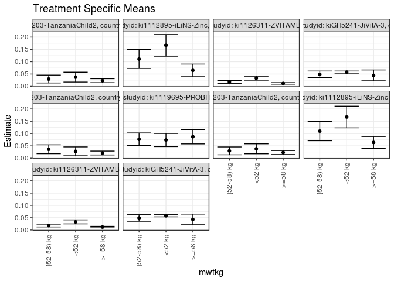

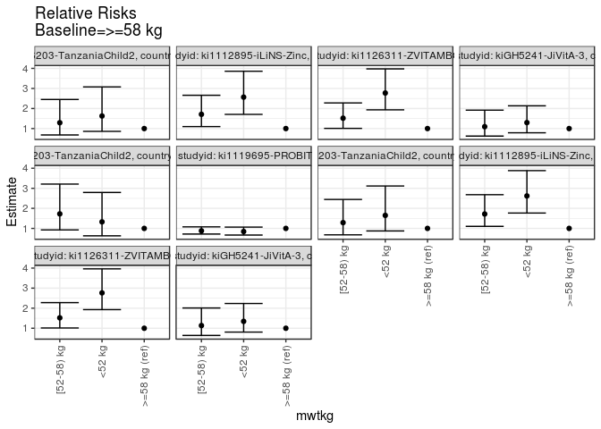

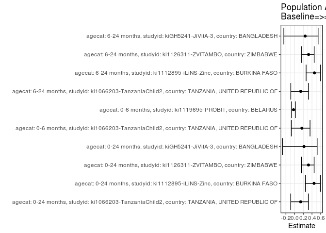

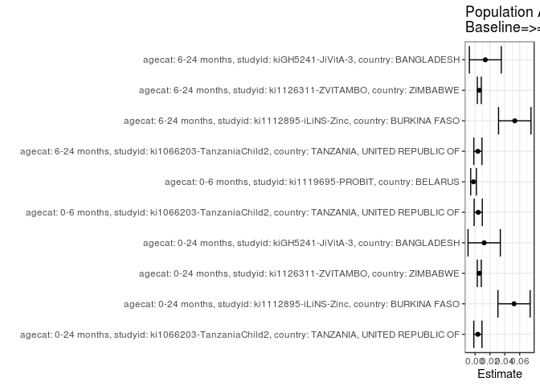

## Results Table

### Parameter: TSM

| agecat | studyid | country | intervention_level | baseline_level | estimate | ci_lower | ci_upper |
| --- | --- | --- | --- | --- | --- | --- | --- |
| 0-24 months | ki1066203-TanzaniaChild2 | TANZANIA, UNITED REPUBLIC OF | >=58 kg | NA | 0.0230798 | 0.0150370 | 0.0311226 |
| 0-24 months | ki1066203-TanzaniaChild2 | TANZANIA, UNITED REPUBLIC OF | <52 kg | NA | 0.0375493 | 0.0175110 | 0.0575876 |
| 0-24 months | ki1066203-TanzaniaChild2 | TANZANIA, UNITED REPUBLIC OF | [52-58) kg | NA | 0.0298213 | 0.0138133 | 0.0458293 |
| 0-24 months | ki1112895-iLiNS-Zinc | BURKINA FASO | >=58 kg | NA | 0.0648759 | 0.0393193 | 0.0904326 |
| 0-24 months | ki1112895-iLiNS-Zinc | BURKINA FASO | <52 kg | NA | 0.1665106 | 0.1223293 | 0.2106919 |
| 0-24 months | ki1112895-iLiNS-Zinc | BURKINA FASO | [52-58) kg | NA | 0.1109266 | 0.0725563 | 0.1492968 |
| 0-24 months | ki1126311-ZVITAMBO | ZIMBABWE | >=58 kg | NA | 0.0119827 | 0.0088424 | 0.0151230 |
| 0-24 months | ki1126311-ZVITAMBO | ZIMBABWE | <52 kg | NA | 0.0332232 | 0.0250060 | 0.0414405 |
| 0-24 months | ki1126311-ZVITAMBO | ZIMBABWE | [52-58) kg | NA | 0.0181719 | 0.0125158 | 0.0238280 |
| 0-24 months | kiGH5241-JiVitA-3 | BANGLADESH | >=58 kg | NA | 0.0445526 | 0.0226497 | 0.0664555 |
| 0-24 months | kiGH5241-JiVitA-3 | BANGLADESH | <52 kg | NA | 0.0577954 | 0.0535043 | 0.0620865 |
| 0-24 months | kiGH5241-JiVitA-3 | BANGLADESH | [52-58) kg | NA | 0.0487756 | 0.0354744 | 0.0620768 |
| 0-6 months | ki1066203-TanzaniaChild2 | TANZANIA, UNITED REPUBLIC OF | >=58 kg | NA | 0.0210117 | 0.0131679 | 0.0288554 |
| 0-6 months | ki1066203-TanzaniaChild2 | TANZANIA, UNITED REPUBLIC OF | <52 kg | NA | 0.0278638 | 0.0099107 | 0.0458168 |
| 0-6 months | ki1066203-TanzaniaChild2 | TANZANIA, UNITED REPUBLIC OF | [52-58) kg | NA | 0.0362319 | 0.0182271 | 0.0542366 |
| 0-6 months | ki1119695-PROBIT | BELARUS | >=58 kg | NA | 0.0872199 | 0.0580268 | 0.1164131 |
| 0-6 months | ki1119695-PROBIT | BELARUS | <52 kg | NA | 0.0736233 | 0.0469909 | 0.1002557 |
| 0-6 months | ki1119695-PROBIT | BELARUS | [52-58) kg | NA | 0.0767565 | 0.0510440 | 0.1024690 |
| 6-24 months | ki1066203-TanzaniaChild2 | TANZANIA, UNITED REPUBLIC OF | >=58 kg | NA | 0.0230511 | 0.0150130 | 0.0310893 |
| 6-24 months | ki1066203-TanzaniaChild2 | TANZANIA, UNITED REPUBLIC OF | <52 kg | NA | 0.0380189 | 0.0178031 | 0.0582347 |
| 6-24 months | ki1066203-TanzaniaChild2 | TANZANIA, UNITED REPUBLIC OF | [52-58) kg | NA | 0.0297005 | 0.0137476 | 0.0456534 |
| 6-24 months | ki1112895-iLiNS-Zinc | BURKINA FASO | >=58 kg | NA | 0.0639133 | 0.0397618 | 0.0880649 |
| 6-24 months | ki1112895-iLiNS-Zinc | BURKINA FASO | <52 kg | NA | 0.1673519 | 0.1231792 | 0.2115245 |
| 6-24 months | ki1112895-iLiNS-Zinc | BURKINA FASO | [52-58) kg | NA | 0.1098554 | 0.0709069 | 0.1488038 |
| 6-24 months | ki1126311-ZVITAMBO | ZIMBABWE | >=58 kg | NA | 0.0119498 | 0.0088289 | 0.0150707 |
| 6-24 months | ki1126311-ZVITAMBO | ZIMBABWE | <52 kg | NA | 0.0330242 | 0.0248488 | 0.0411996 |
| 6-24 months | ki1126311-ZVITAMBO | ZIMBABWE | [52-58) kg | NA | 0.0181638 | 0.0125525 | 0.0237751 |
| 6-24 months | kiGH5241-JiVitA-3 | BANGLADESH | >=58 kg | NA | 0.0430179 | 0.0213754 | 0.0646603 |
| 6-24 months | kiGH5241-JiVitA-3 | BANGLADESH | <52 kg | NA | 0.0578148 | 0.0535230 | 0.0621066 |
| 6-24 months | kiGH5241-JiVitA-3 | BANGLADESH | [52-58) kg | NA | 0.0488259 | 0.0354804 | 0.0621714 |

### Parameter: E(Y)

| agecat | studyid | country | intervention_level | baseline_level | estimate | ci_lower | ci_upper |
| --- | --- | --- | --- | --- | --- | --- | --- |
| 0-24 months | ki1066203-TanzaniaChild2 | TANZANIA, UNITED REPUBLIC OF | NA | NA | 0.0268109 | 0.0199430 | 0.0336788 |
| 0-24 months | ki1112895-iLiNS-Zinc | BURKINA FASO | NA | NA | 0.1173252 | 0.0921861 | 0.1424644 |
| 0-24 months | ki1126311-ZVITAMBO | ZIMBABWE | NA | NA | 0.0176014 | 0.0149065 | 0.0202963 |
| 0-24 months | kiGH5241-JiVitA-3 | BANGLADESH | NA | NA | 0.0567901 | 0.0526750 | 0.0609052 |
| 0-6 months | ki1066203-TanzaniaChild2 | TANZANIA, UNITED REPUBLIC OF | NA | NA | 0.0252226 | 0.0183864 | 0.0320587 |
| 0-6 months | ki1119695-PROBIT | BELARUS | NA | NA | 0.0851193 | 0.0573651 | 0.1128734 |
| 6-24 months | ki1066203-TanzaniaChild2 | TANZANIA, UNITED REPUBLIC OF | NA | NA | 0.0268109 | 0.0199430 | 0.0336788 |
| 6-24 months | ki1112895-iLiNS-Zinc | BURKINA FASO | NA | NA | 0.1173252 | 0.0921861 | 0.1424644 |
| 6-24 months | ki1126311-ZVITAMBO | ZIMBABWE | NA | NA | 0.0176014 | 0.0149065 | 0.0202963 |
| 6-24 months | kiGH5241-JiVitA-3 | BANGLADESH | NA | NA | 0.0567901 | 0.0526750 | 0.0609052 |

### Parameter: RR

| agecat | studyid | country | intervention_level | baseline_level | estimate | ci_lower | ci_upper |
| --- | --- | --- | --- | --- | --- | --- | --- |
| 0-24 months | ki1066203-TanzaniaChild2 | TANZANIA, UNITED REPUBLIC OF | >=58 kg | >=58 kg | 1.0000000 | 1.0000000 | 1.000000 |
| 0-24 months | ki1066203-TanzaniaChild2 | TANZANIA, UNITED REPUBLIC OF | <52 kg | >=58 kg | 1.6269348 | 0.8601133 | 3.077405 |
| 0-24 months | ki1066203-TanzaniaChild2 | TANZANIA, UNITED REPUBLIC OF | [52-58) kg | >=58 kg | 1.2920960 | 0.6813737 | 2.450215 |
| 0-24 months | ki1112895-iLiNS-Zinc | BURKINA FASO | >=58 kg | >=58 kg | 1.0000000 | 1.0000000 | 1.000000 |
| 0-24 months | ki1112895-iLiNS-Zinc | BURKINA FASO | <52 kg | >=58 kg | 2.5665999 | 1.7070500 | 3.858958 |
| 0-24 months | ki1112895-iLiNS-Zinc | BURKINA FASO | [52-58) kg | >=58 kg | 1.7098262 | 1.0991388 | 2.659815 |
| 0-24 months | ki1126311-ZVITAMBO | ZIMBABWE | >=58 kg | >=58 kg | 1.0000000 | 1.0000000 | 1.000000 |
| 0-24 months | ki1126311-ZVITAMBO | ZIMBABWE | <52 kg | >=58 kg | 2.7725928 | 1.9336570 | 3.975509 |
| 0-24 months | ki1126311-ZVITAMBO | ZIMBABWE | [52-58) kg | >=58 kg | 1.5165104 | 1.0095085 | 2.278142 |
| 0-24 months | kiGH5241-JiVitA-3 | BANGLADESH | >=58 kg | >=58 kg | 1.0000000 | 1.0000000 | 1.000000 |
| 0-24 months | kiGH5241-JiVitA-3 | BANGLADESH | <52 kg | >=58 kg | 1.2972382 | 0.7888264 | 2.133330 |
| 0-24 months | kiGH5241-JiVitA-3 | BANGLADESH | [52-58) kg | >=58 kg | 1.0947859 | 0.6244645 | 1.919334 |
| 0-6 months | ki1066203-TanzaniaChild2 | TANZANIA, UNITED REPUBLIC OF | >=58 kg | >=58 kg | 1.0000000 | 1.0000000 | 1.000000 |
| 0-6 months | ki1066203-TanzaniaChild2 | TANZANIA, UNITED REPUBLIC OF | <52 kg | >=58 kg | 1.3261094 | 0.6297729 | 2.792381 |
| 0-6 months | ki1066203-TanzaniaChild2 | TANZANIA, UNITED REPUBLIC OF | [52-58) kg | >=58 kg | 1.7243693 | 0.9261992 | 3.210378 |
| 0-6 months | ki1119695-PROBIT | BELARUS | >=58 kg | >=58 kg | 1.0000000 | 1.0000000 | 1.000000 |
| 0-6 months | ki1119695-PROBIT | BELARUS | <52 kg | >=58 kg | 0.8441110 | 0.6685351 | 1.065798 |
| 0-6 months | ki1119695-PROBIT | BELARUS | [52-58) kg | >=58 kg | 0.8800336 | 0.7187409 | 1.077522 |
| 6-24 months | ki1066203-TanzaniaChild2 | TANZANIA, UNITED REPUBLIC OF | >=58 kg | >=58 kg | 1.0000000 | 1.0000000 | 1.000000 |
| 6-24 months | ki1066203-TanzaniaChild2 | TANZANIA, UNITED REPUBLIC OF | <52 kg | >=58 kg | 1.6493295 | 0.8732118 | 3.115267 |
| 6-24 months | ki1066203-TanzaniaChild2 | TANZANIA, UNITED REPUBLIC OF | [52-58) kg | >=58 kg | 1.2884613 | 0.6791585 | 2.444396 |
| 6-24 months | ki1112895-iLiNS-Zinc | BURKINA FASO | >=58 kg | >=58 kg | 1.0000000 | 1.0000000 | 1.000000 |
| 6-24 months | ki1112895-iLiNS-Zinc | BURKINA FASO | <52 kg | >=58 kg | 2.6184185 | 1.7659955 | 3.882295 |
| 6-24 months | ki1112895-iLiNS-Zinc | BURKINA FASO | [52-58) kg | >=58 kg | 1.7188176 | 1.1020604 | 2.680737 |
| 6-24 months | ki1126311-ZVITAMBO | ZIMBABWE | >=58 kg | >=58 kg | 1.0000000 | 1.0000000 | 1.000000 |
| 6-24 months | ki1126311-ZVITAMBO | ZIMBABWE | <52 kg | >=58 kg | 2.7635817 | 1.9282360 | 3.960814 |
| 6-24 months | ki1126311-ZVITAMBO | ZIMBABWE | [52-58) kg | >=58 kg | 1.5200094 | 1.0142980 | 2.277860 |
| 6-24 months | kiGH5241-JiVitA-3 | BANGLADESH | >=58 kg | >=58 kg | 1.0000000 | 1.0000000 | 1.000000 |
| 6-24 months | kiGH5241-JiVitA-3 | BANGLADESH | <52 kg | >=58 kg | 1.3439720 | 0.8080571 | 2.235313 |
| 6-24 months | kiGH5241-JiVitA-3 | BANGLADESH | [52-58) kg | >=58 kg | 1.1350144 | 0.6409071 | 2.010054 |

### Parameter: PAR

| agecat | studyid | country | intervention_level | baseline_level | estimate | ci_lower | ci_upper |
| --- | --- | --- | --- | --- | --- | --- | --- |
| 0-24 months | ki1066203-TanzaniaChild2 | TANZANIA, UNITED REPUBLIC OF | >=58 kg | NA | 0.0037311 | -0.0017649 | 0.0092272 |
| 0-24 months | ki1112895-iLiNS-Zinc | BURKINA FASO | >=58 kg | NA | 0.0524493 | 0.0307699 | 0.0741287 |
| 0-24 months | ki1126311-ZVITAMBO | ZIMBABWE | >=58 kg | NA | 0.0056187 | 0.0029459 | 0.0082914 |
| 0-24 months | kiGH5241-JiVitA-3 | BANGLADESH | >=58 kg | NA | 0.0122375 | -0.0094949 | 0.0339699 |
| 0-6 months | ki1066203-TanzaniaChild2 | TANZANIA, UNITED REPUBLIC OF | >=58 kg | NA | 0.0042109 | -0.0012717 | 0.0096935 |
| 0-6 months | ki1119695-PROBIT | BELARUS | >=58 kg | NA | -0.0021007 | -0.0059265 | 0.0017252 |
| 6-24 months | ki1066203-TanzaniaChild2 | TANZANIA, UNITED REPUBLIC OF | >=58 kg | NA | 0.0037598 | -0.0017344 | 0.0092539 |
| 6-24 months | ki1112895-iLiNS-Zinc | BURKINA FASO | >=58 kg | NA | 0.0534119 | 0.0315863 | 0.0752375 |
| 6-24 months | ki1126311-ZVITAMBO | ZIMBABWE | >=58 kg | NA | 0.0056516 | 0.0029955 | 0.0083077 |
| 6-24 months | kiGH5241-JiVitA-3 | BANGLADESH | >=58 kg | NA | 0.0137723 | -0.0077034 | 0.0352479 |

### Parameter: PAF

| agecat | studyid | country | intervention_level | baseline_level | estimate | ci_lower | ci_upper |
| --- | --- | --- | --- | --- | --- | --- | --- |
| 0-24 months | ki1066203-TanzaniaChild2 | TANZANIA, UNITED REPUBLIC OF | >=58 kg | NA | 0.1391642 | -0.0886062 | 0.3192780 |
| 0-24 months | ki1112895-iLiNS-Zinc | BURKINA FASO | >=58 kg | NA | 0.4470419 | 0.2486425 | 0.5930530 |
| 0-24 months | ki1126311-ZVITAMBO | ZIMBABWE | >=58 kg | NA | 0.3192169 | 0.1587349 | 0.4490849 |
| 0-24 months | kiGH5241-JiVitA-3 | BANGLADESH | >=58 kg | NA | 0.2154863 | -0.2769179 | 0.5180099 |
| 0-6 months | ki1066203-TanzaniaChild2 | TANZANIA, UNITED REPUBLIC OF | >=58 kg | NA | 0.1669490 | -0.0755193 | 0.3547544 |
| 0-6 months | ki1119695-PROBIT | BELARUS | >=58 kg | NA | -0.0246791 | -0.0686757 | 0.0175062 |
| 6-24 months | ki1066203-TanzaniaChild2 | TANZANIA, UNITED REPUBLIC OF | >=58 kg | NA | 0.1402326 | -0.0874513 | 0.3202454 |
| 6-24 months | ki1112895-iLiNS-Zinc | BURKINA FASO | >=58 kg | NA | 0.4552463 | 0.2644584 | 0.5965469 |
| 6-24 months | ki1126311-ZVITAMBO | ZIMBABWE | >=58 kg | NA | 0.3210886 | 0.1619342 | 0.4500186 |
| 6-24 months | kiGH5241-JiVitA-3 | BANGLADESH | >=58 kg | NA | 0.2425116 | -0.2469982 | 0.5398641 |